# Lab week 1 - penalized linear models

Data Science 2: Machine Learning Concepts - CEU 2021

Janos K. Divenyi, Jeno Pal

2021-02-08

```r
library(data.table)
library(ggplot2)
library(GGally)   # ggplot extensions
library(caret)
library(magrittr)
library(skimr)
library(janitor)  # for data cleaning purposes
library(glmnet)   # the main package for penalized linear models
library(broom)    # for tidying regression coefficient outputs
library(knitr)
library(kableExtra)  # for nicer tables in rmarkdown

theme_set(theme_bw())   # globally set ggplot theme
```

Disclaimer: this lab borrows lots of ideas and examples from [this](https://afit-r.github.io/regularized_regression) great tutorial.

## Data: Ames Housing dataset

We are going to predict house sales prices in Ames, Iowa. See [here](https://cran.r-project.org/web/packages/AmesHousing/index.html).

```r
skim(housing_data)
```

```
── Data Summary ────────────────────────
                           Values
Name                       housing_data
Number of rows             2930
Number of columns          81
_______________________
Column type frequency:
  factor                   46
  numeric                  35
________________________
Group variables            None

── Variable type: factor ─────────────────────────────────────────────────────────────────────────────────────────────────────────────
   skim_variable   n_missing complete_rate ordered n_unique top_counts
 1 ms_sub_class            0             1 FALSE         16 One: 1079, Two: 575, One: 287, One: 192
```

[output cut: 83 more lines]

Look at the outcome variable, the price of houses.

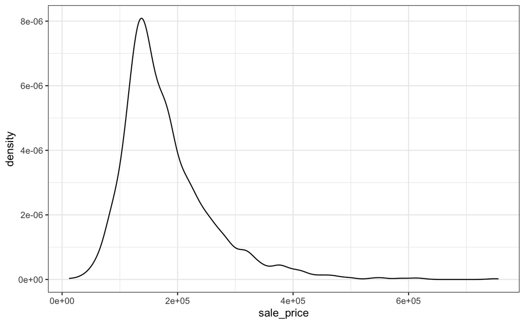

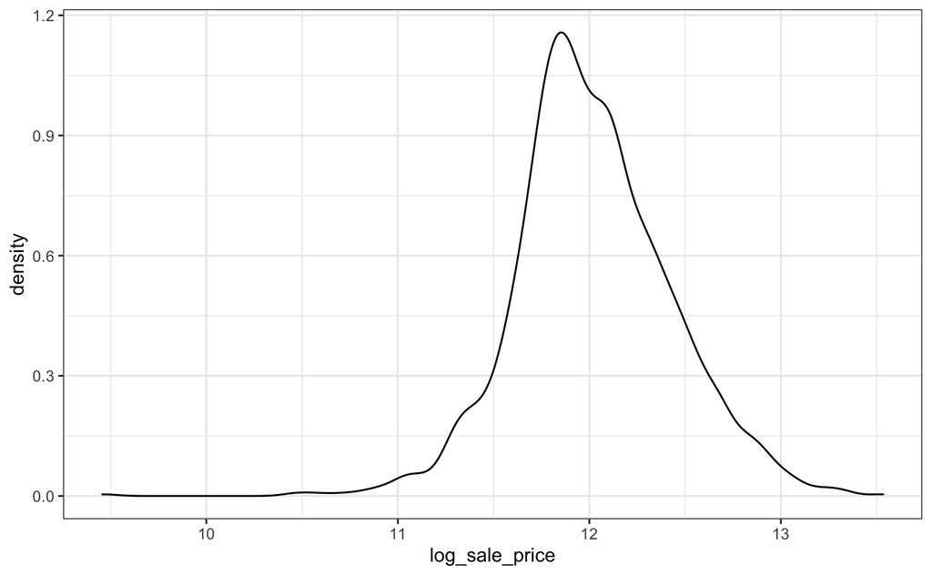

Let’s see correlations of features and the outcome variable. Based on this, simple benchmark models can quickly be put together.

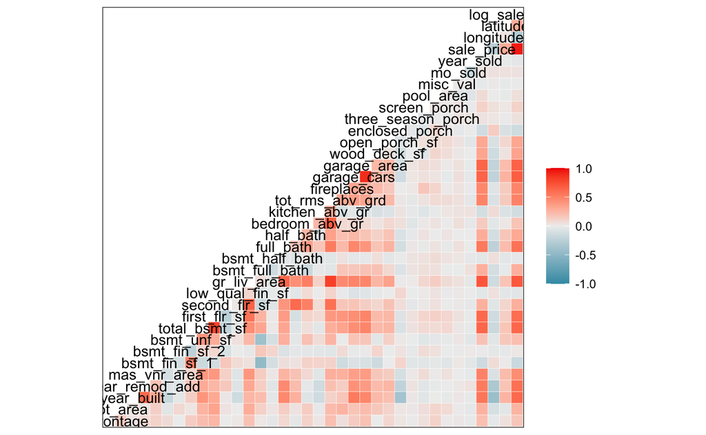

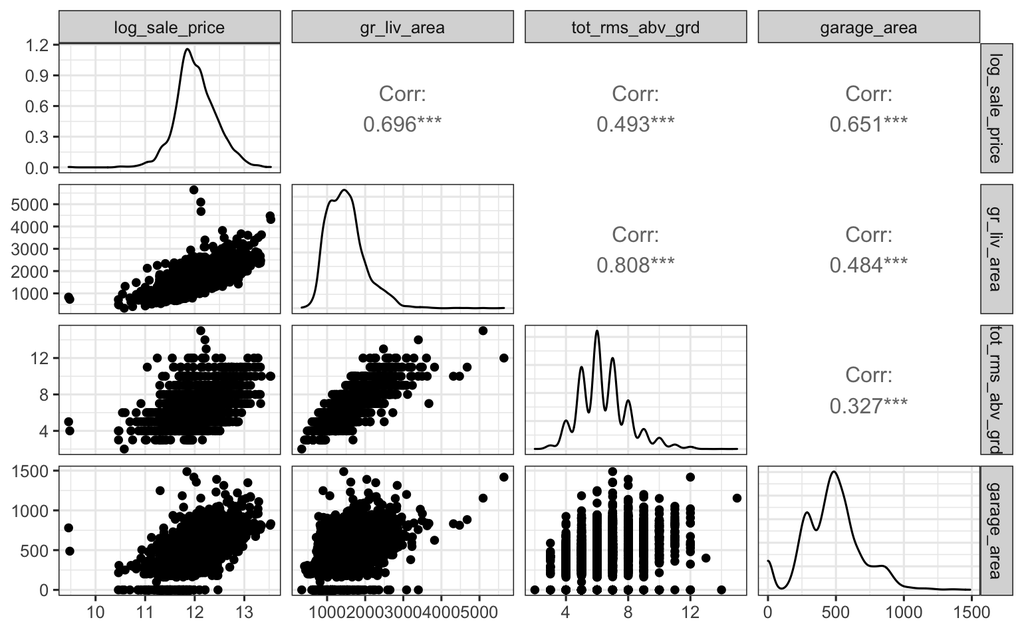

### A baseline model

| term | estimate | std.error | statistic | p.value |
| --- | --- | --- | --- | --- |
| (Intercept) | 11.318 | 0.023 | 498.266 | 0 |
| gr_liv_area | 0.001 | 0.000 | 38.602 | 0 |
| tot_rms_abv_grd | -0.052 | 0.006 | -9.006 | 0 |

Weird pattern: sales price decreases with the number of rooms? This is spurious and is caused by the high positive correlation between the feature variables. Univariate regressions have the intuitive signs:

| term | estimate | std.error | statistic | p.value |
| --- | --- | --- | --- | --- |
| (Intercept) | 11.180 | 0.017 | 660.123 | 0 |
| gr_liv_area | 0.001 | 0.000 | 52.430 | 0 |

| term | estimate | std.error | statistic | p.value |
| --- | --- | --- | --- | --- |
| (Intercept) | 11.199 | 0.028 | 405.172 | 0 |
| tot_rms_abv_grd | 0.128 | 0.004 | 30.627 | 0 |

Penalized methods offer a solution to these kinds of patterns.

### Set up training and test (holdout) datasets

```r
data_train <- housing_data[train_indices, ]
```

```
The `i` argument of ``[`()` can't be a matrix as of tibble 3.0.0.
Convert to a vector.
```

## Penalize large coefficients: the Ridge regression

The ridge regression adds a penalty term to the sum of squared residuals: the sum of squares of the regression coefficients. This puts a cost on having large coefficients. Result: biased but lower variance model.

```r
features <- setdiff(names(housing_data), c("sale_price", "log_sale_price"))
```

First we are going to directly work with the `glmnet` package to estimate penalized models. Then we look at how this can be implemented through `caret`.

```r
# glmnet needs inputs as a matrix. model.matrix: handles factor variables
# -1: we do not need the intercept as glment will automatically include it
x_train <- model.matrix( ~ . -1, data_train[, features, with = FALSE])
dim(x_train)
```

```
[1] 2053  309
```

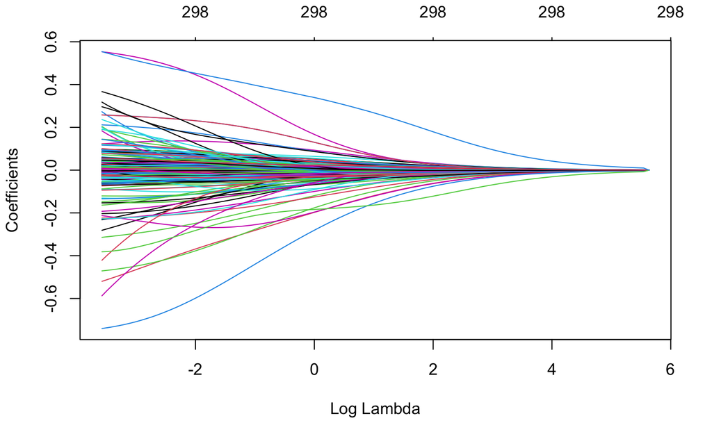

```r
# standardization of variables is automatically done by glmnet

# how much penalty do we want to apply? select with CV
lambda_grid <- 10^seq(2,-5,length=100)

set.seed(1234)
ridge_model <- glmnet(
  x = x_train, y = data_train[["log_sale_price"]],
  family = "gaussian", # for continuous response
  alpha = 0  # the ridge model
)

plot(ridge_model, xvar = "lambda")
```

Look at some individual coefficients.

```r
# helper function to extract the coefficient sequence as a data.table
get_glmnet_coeff_sequence <- function(glmnet_model) {
  coeff_sequence <- coef(glmnet_model) %>% tidy()
  names(coeff_sequence) <- c("variable", "lambda_id", "value")

  lambdas <- tibble(
    lambda = glmnet_model$lambda,
    lambda_id = paste0("s", 0:(length(glmnet_model$lambda) - 1))
  )

  dplyr::inner_join(coeff_sequence, lambdas, by = "lambda_id")
}
get_glmnet_coeff_sequence <- function(glmnet_model) {
  coeff_sequence <- coef(glmnet_model) %>% tidy()
  names(coeff_sequence) <- c("variable", "lambda_id", "value")

  lambdas <- tibble(
    lambda = glmnet_model$lambda,
    lambda_id = paste0("s", 0:(length(glmnet_model$lambda) - 1))
  )

  dplyr::inner_join(coeff_sequence, lambdas, by = "lambda_id")
}
```

```r
ridge_coeffs <- get_glmnet_coeff_sequence(ridge_model)
```

```
'tidy.dgCMatrix' is deprecated.
See help("Deprecated")'tidy.dgTMatrix' is deprecated.
See help("Deprecated")
```

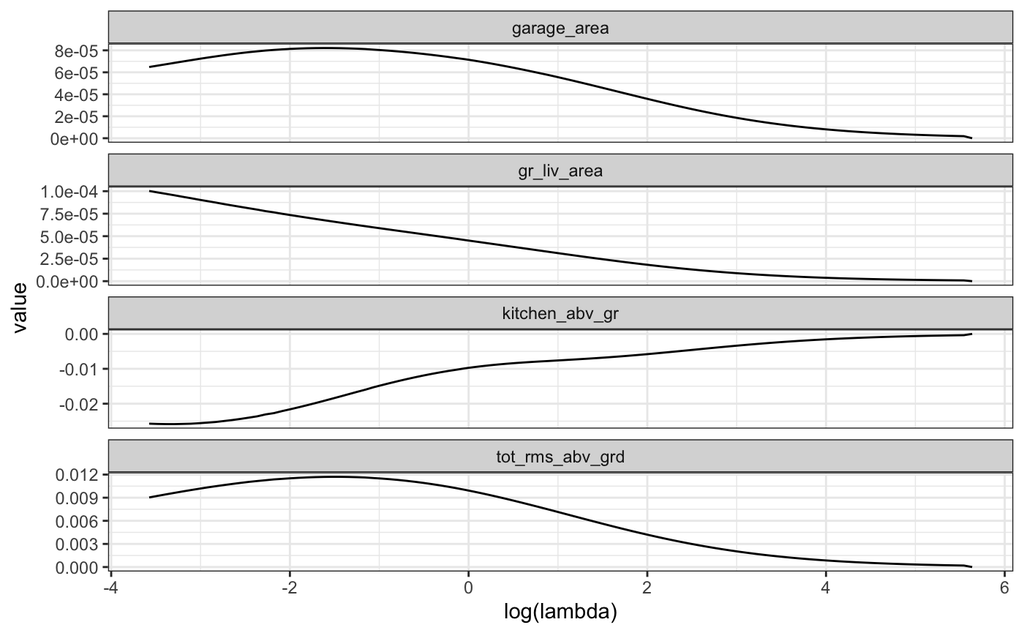

```r
selected_variables <- c("gr_liv_area", "tot_rms_abv_grd", "garage_area",  "kitchen_abv_gr")
ggplot(
  data = ridge_coeffs %>% filter(variable %in% selected_variables),
  aes(x = log(lambda), y = value)) +
    geom_line() +
  facet_wrap(~ variable, scales = "free_y", ncol = 1)
```

We can use cross-validation to determine the optimal penalty term weight. Two lambda values marked on the plot: one with the minimal CV RMSE, the other is the simplest model (highest lambda) which contains the optimal lambda’s error within one standard deviation. That is, it gives the simplest model that is still “good enough”.

```r
set.seed(1234)
ridge_model_cv <- cv.glmnet(
  x = x_train, y = data_train[["log_sale_price"]],
  family = "gaussian",
  alpha = 0,
  nfolds = 10
)

best_lambda <- ridge_model_cv$lambda.min
message(paste0("The optimally chosen penalty parameter: ", best_lambda))
```

```
The optimally chosen penalty parameter: 0.180129135344916
```

```r
highest_good_enough_lambda <- ridge_model_cv$lambda.1se
message(paste0("The highest good enough penalty parameter: ", highest_good_enough_lambda))
```

```
The highest good enough penalty parameter: 0.875896216853839
```

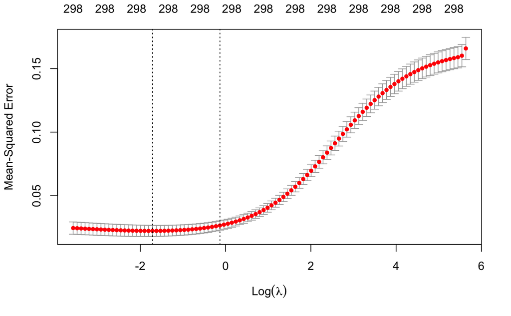

```r
plot(ridge_model_cv)
```

We can also use `caret` to estimate ridge models. This lets us compare it later to any other model estimated with caret, using, for example, cross-validation with exactly the same folds.

```r
# ridge model
ridge_tune_grid <- expand.grid(
  "alpha" = c(0),
  "lambda" = seq(0.05, 0.5, by = 0.025)
)

set.seed(857)
ridge_fit <- train(
  log_sale_price ~ . -sale_price,
  data = data_train,
  method = "glmnet",
  preProcess = c("center", "scale"),
  tuneGrid = ridge_tune_grid,
  trControl = fit_control
)
```

```r
ridge_fit
```

```
glmnet

2053 samples
  81 predictor

Pre-processing: centered (308), scaled (308)
Resampling: Cross-Validated (10 fold)
Summary of sample sizes: 1847, 1849, 1849, 1847, 1848, 1847, ...
Resampling results across tuning parameters:

  lambda  RMSE       Rsquared   MAE
  0.050   0.1464742  0.8707003  0.08654948
  0.075   0.1446715  0.8732402  0.08641530
  0.100   0.1436810  0.8746908  0.08668066
  0.125   0.1431577  0.8755367  0.08716370
  0.150   0.1429352  0.8760033  0.08772921
  0.175   0.1429234  0.8762089  0.08830684
  0.200   0.1430586  0.8762391  0.08891297
  0.225   0.1433025  0.8761429  0.08951049
  0.250   0.1436295  0.8759524  0.09012103
  0.275   0.1440211  0.8756904  0.09074102
  0.300   0.1444622  0.8753753  0.09135751
  0.325   0.1449408  0.8750214  0.09196578
  0.350   0.1454497  0.8746372  0.09257827
  0.375   0.1459867  0.8742271  0.09318557
  0.400   0.1465406  0.8737999  0.09377238
  0.425   0.1471172  0.8733518  0.09436542
  0.450   0.1477083  0.8728943  0.09495540
  0.475   0.1483059  0.8724337  0.09554946
  0.500   0.1489224  0.8719555  0.09615197

Tuning parameter 'alpha' was held constant at a value of 0
RMSE was used to select the optimal model using the smallest value.
The final values used for the model were alpha = 0 and lambda = 0.175.
```

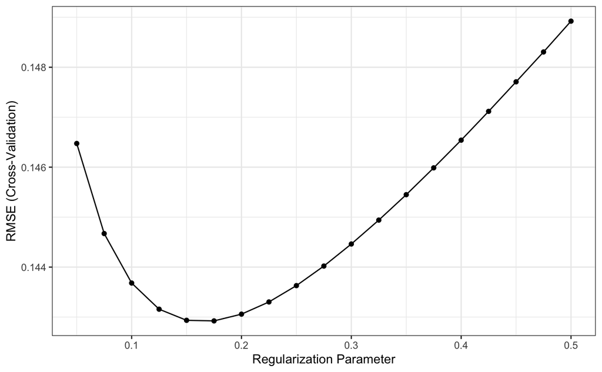

```r
ggplot(ridge_fit)
```

## Another variant: LASSO regression

While Ridge applies a constraint on the sum of squares of coefficients, LASSO does the same for the sum of the **absolute values** of coefficients.

This seemingly small difference has important sconsequences: some coefficients are set exactly to zero, others are only shrunk towards zero.

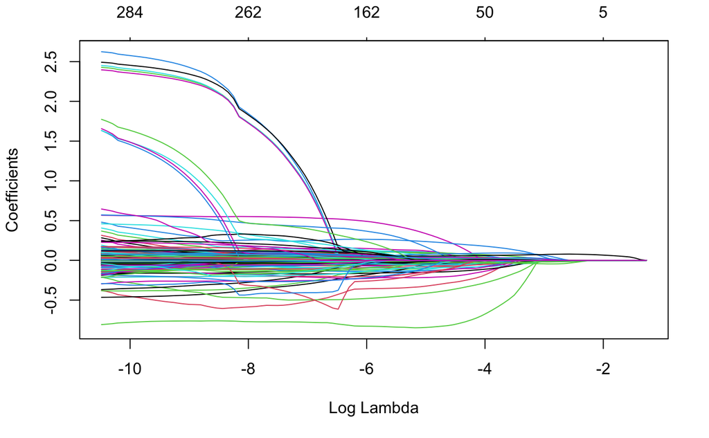

```r
set.seed(1234)
lasso_model <- glmnet(
  x = x_train, y = data_train[["log_sale_price"]],
  family = "gaussian",
  alpha = 1  # the lasso model
)

plot(lasso_model, xvar = "lambda")
```

```r
lasso_coeffs <- get_glmnet_coeff_sequence(lasso_model)
```

```
'tidy.dgCMatrix' is deprecated.
See help("Deprecated")'tidy.dgTMatrix' is deprecated.
See help("Deprecated")
```

```r
selected_variables <- c("gr_liv_area", "tot_rms_abv_grd", "garage_area", "kitchen_abv_gr")
ggplot(
  data = lasso_coeffs[variable %in% selected_variables],
  aes(x = log(lambda), y = value)) +
    geom_line() +
  facet_wrap(~ variable, scales = "free_y", ncol = 1)
```

[output not shown]

```
Error in variable %in% selected_variables : object 'variable' not found
```

Again, we can apply cross-validation to determine the optimal value for the penalty term.

```r
set.seed(1234)
lasso_model_cv <- cv.glmnet(
  x = x_train, y = data_train[["log_sale_price"]],
  family = "gaussian",
  alpha = 1,
  nfolds = 10
)

best_lambda <- lasso_model_cv$lambda.min
message(paste0("The optimally chosen penalty parameter: ", best_lambda))
```

```
The optimally chosen penalty parameter: 0.00388076456762921
```

```r
highest_good_enough_lambda <- lasso_model_cv$lambda.1se
message(paste0("The highest good enough penalty parameter: ", highest_good_enough_lambda))
```

```
The highest good enough penalty parameter: 0.0227297188251623
```

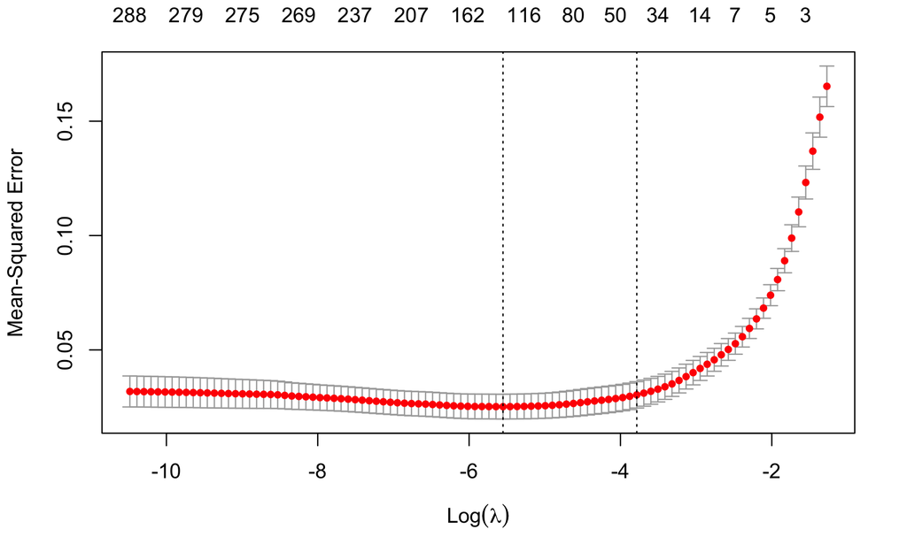

```r
plot(lasso_model_cv)
```

Fitting LASSO models with `caret` is similar to that of Ridge.

```r
tenpowers <- 10^seq(-1, -5, by = -1)

lasso_tune_grid <- expand.grid(
  "alpha" = c(1),
  "lambda" = c(tenpowers, tenpowers / 2)
)

set.seed(857)
lasso_fit <- train(
  log_sale_price ~ . -sale_price,
  data = data_train,
  method = "glmnet",
  preProcess = c("center", "scale"),
  tuneGrid = lasso_tune_grid,
  trControl = fit_control
)
```

```r
lasso_fit
```

```
glmnet

2053 samples
  81 predictor

Pre-processing: centered (308), scaled (308)
Resampling: Cross-Validated (10 fold)
Summary of sample sizes: 1847, 1849, 1849, 1847, 1848, 1847, ...
Resampling results across tuning parameters:

  lambda  RMSE       Rsquared   MAE
  5e-06   0.1724948  0.8316208  0.08760109
  1e-05   0.1724948  0.8316208  0.08760109
  5e-05   0.1719195  0.8325130  0.08753221
  1e-04   0.1701065  0.8353641  0.08724015
  5e-04   0.1608812  0.8493622  0.08610976
  1e-03   0.1549066  0.8580135  0.08566133
  5e-03   0.1481077  0.8664453  0.08711685
  1e-02   0.1534121  0.8580125  0.09303712
  5e-02   0.1970917  0.8002051  0.13039984
  1e-01   0.2394941  0.7692260  0.16621033

Tuning parameter 'alpha' was held constant at a value of 1
RMSE was used to select the optimal model using the smallest value.
The final values used for the model were alpha = 1 and lambda = 0.005.
```

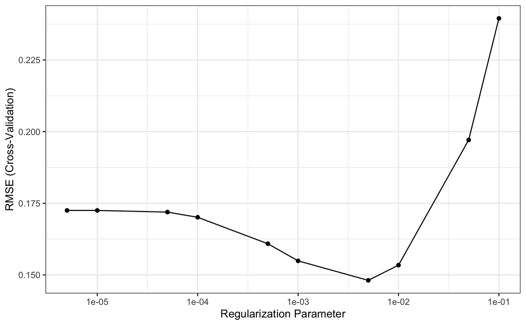

```r
ggplot(lasso_fit) + scale_x_log10()
```

### Variable selection - why is it happening?

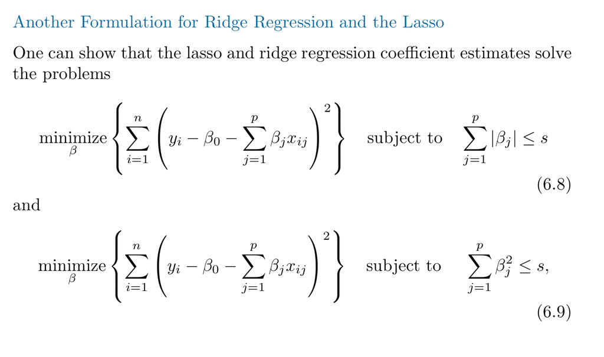

The constraints are different: LASSO’s has corners, Ridge’s is smooth. Corners mean some coefficients being exactly zero.

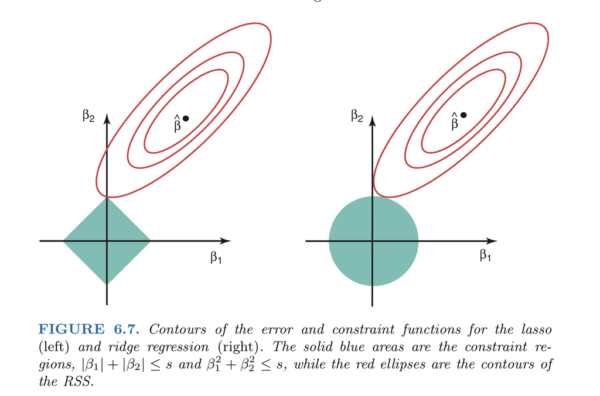

Source: Introduction to Statistical Learning

## Combine Ridge and LASSO: Elastic net

We can combine both types of penalties. LASSO is attractive since it performs principled variable selection. However, when having correlated features, typically only one of them - quite arbitrarily - is kept in the model. Ridge simultaneously shrinks coefficients of these towards zero. If we apply penalties of both the absolute values and the squares of the coefficients, both virtues are retained. This method is called Elastic net.

```r
enet_tune_grid <- expand.grid(
  "alpha" = seq(0, 1, by = 0.1),
  "lambda" = union(lasso_tune_grid[["lambda"]], ridge_tune_grid[["lambda"]])
)

set.seed(857)
enet_fit <- train(
  log_sale_price ~ . -sale_price,
  data = data_train,
  method = "glmnet",
  preProcess = c("center", "scale"),
  tuneGrid = enet_tune_grid,
  trControl = fit_control
)
```

```r
enet_fit
```

```
glmnet

2053 samples
  81 predictor

Pre-processing: centered (308), scaled (308)
Resampling: Cross-Validated (10 fold)
Summary of sample sizes: 1847, 1849, 1849, 1847, 1848, 1847, ...
Resampling results across tuning parameters:

  alpha  lambda    RMSE       Rsquared   MAE
  0.0    0.000005  0.1494346  0.8665309  0.08716389
  0.0    0.000010  0.1494346  0.8665309  0.08716389
  0.0    0.000050  0.1494346  0.8665309  0.08716389
  0.0    0.000100  0.1494346  0.8665309  0.08716389
  0.0    0.000500  0.1494346  0.8665309  0.08716389
  0.0    0.001000  0.1494346  0.8665309  0.08716389
  0.0    0.005000  0.1494346  0.8665309  0.08716389
  0.0    0.010000  0.1494346  0.8665309  0.08716389
  0.0    0.050000  0.1464742  0.8707003  0.08654948
  0.0    0.075000  0.1446715  0.8732402  0.08641530
  0.0    0.100000  0.1436810  0.8746908  0.08668066
  0.0    0.125000  0.1431577  0.8755367  0.08716370
  0.0    0.150000  0.1429352  0.8760033  0.08772921
  0.0    0.175000  0.1429234  0.8762089  0.08830684
  0.0    0.200000  0.1430586  0.8762391  0.08891297
  0.0    0.225000  0.1433025  0.8761429  0.08951049
  0.0    0.250000  0.1436295  0.8759524  0.09012103
  0.0    0.275000  0.1440211  0.8756904  0.09074102
  0.0    0.300000  0.1444622  0.8753753  0.09135751
  0.0    0.325000  0.1449408  0.8750214  0.09196578
  0.0    0.350000  0.1454497  0.8746372  0.09257827
  0.0    0.375000  0.1459867  0.8742271  0.09318557
  0.0    0.400000  0.1465406  0.8737999  0.09377238
  0.0    0.425000  0.1471172  0.8733518  0.09436542
  0.0    0.450000  0.1477083  0.8728943  0.09495540
  0.0    0.475000  0.1483059  0.8724337  0.09554946
  0.0    0.500000  0.1489224  0.8719555  0.09615197
  0.1    0.000005  0.1670353  0.8403192  0.08758031
  0.1    0.000010  0.1670353  0.8403192  0.08758031
```

[output cut: 160 more lines]

```
  0.7    0.000005  0.1716968  0.8329255  0.08750992
  0.7    0.000010  0.1716968  0.8329255  0.08750992
  0.7    0.000050  0.1715011  0.8332347  0.08750053
  0.7    0.000100  0.1699035  0.8357798  0.08731974
  0.7    0.000500  0.1623243  0.8473529  0.08657680
  0.7    0.001000  0.1571805  0.8548542  0.08587782
  0.7    0.005000  0.1470432  0.8684973  0.08590511
  0.7    0.010000  0.1492584  0.8646990  0.08925266
  0.7    0.050000  0.1809722  0.8231889  0.11816131
  0.7    0.075000  0.2000806  0.8012626  0.13291098
  0.7    0.100000  0.2161021  0.7885254  0.14579813
 [ reached getOption("max.print") -- omitted 97 rows ]

RMSE was used to select the optimal model using the smallest value.
The final values used for the model were alpha = 0 and lambda = 0.175.
```

## Evaluate all models

For completeness, estimate the non-regularized linear model as well.

```r
set.seed(857)
linear_fit <- train(
  log_sale_price ~ . -sale_price,
  data = data_train,
  method = "lm",
  preProcess = c("center", "scale"),
  trControl = fit_control
)
```

```r
resample_profile <- resamples(
  list("linear" = linear_fit,
       "ridge" = ridge_fit,
       "lasso" = lasso_fit,
       "elastic net" = enet_fit
  )
)
summary(resample_profile)
```

```
Call:
summary.resamples(object = resample_profile)

Models: linear, ridge, lasso, elastic net
Number of resamples: 10

MAE
                  Min.    1st Qu.     Median       Mean    3rd Qu.      Max. NA's
linear      0.07777197 0.07940461 0.09265443 0.08873995 0.09527491 0.0987329    0
ridge       0.07367948 0.08026915 0.08802844 0.08830684 0.09413163 0.1061065    0
lasso       0.07086193 0.08087593 0.08594562 0.08711685 0.09203586 0.1047683    0
elastic net 0.07367948 0.08026915 0.08802844 0.08830684 0.09413163 0.1061065    0

RMSE
                  Min.   1st Qu.    Median      Mean   3rd Qu.      Max. NA's
linear      0.11238141 0.1364270 0.1721632 0.1771764 0.2204885 0.2404686    0
ridge       0.09860469 0.1175353 0.1319301 0.1429234 0.1472833 0.2196785    0
lasso       0.09536545 0.1233744 0.1333620 0.1481077 0.1520182 0.2372004    0
elastic net 0.09860469 0.1175353 0.1319301 0.1429234 0.1472833 0.2196785    0

Rsquared
                 Min.   1st Qu.    Median      Mean   3rd Qu.      Max. NA's
linear      0.7147800 0.7634893 0.8286702 0.8249801 0.8875117 0.9207508    0
ridge       0.7488259 0.8582377 0.8939727 0.8762089 0.9185868 0.9253607    0
lasso       0.7119918 0.8498486 0.8874229 0.8664453 0.9117261 0.9298672    0
elastic net 0.7488259 0.8582377 0.8939727 0.8762089 0.9185868 0.9253607    0
```

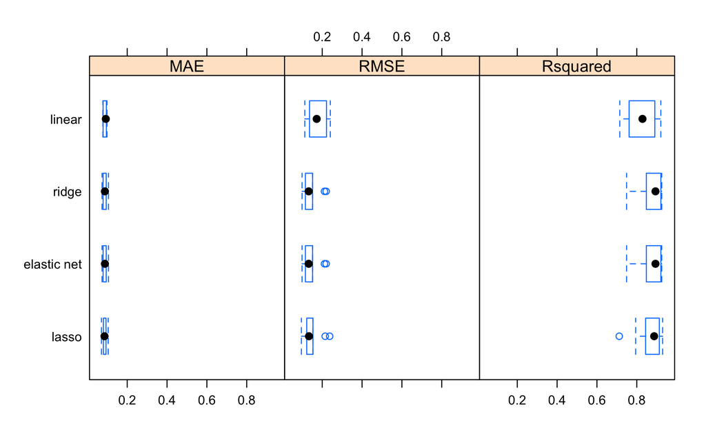

Are differences between models large in a statistical sense? Not really. What we can certainly see is that the plain linear model’s variance is much larger than that of the penalized ones.

```r
model_differences <- diff(resample_profile)
```

```r
summary(model_differences)
```

[figure not shown]

### Evaluate the chosen model on holdout set

```r
RMSE(predict(enet_fit, newdata = data_test), data_test[["log_sale_price"]])
```

[output not shown]

## Recommended readings

- [Tutorial of the Air Force Institute of Technology](https://afit-r.github.io/regularized_regression) - based on which this lab was put together
- [Elements of Statistical Learning](https://web.stanford.edu/~hastie/ElemStatLearn/) - the standard reference book of machine learning (freely available)
- [Introduction to Statistical Learning](http://www-bcf.usc.edu/~gareth/ISL/) - a more accessible treatment of the same material from the same authors (with R codes)
- [Applied Predictive Modelling](http://appliedpredictivemodeling.com/) - a thorough and practical guide to predictive modelling from the author of the `caret` package (with R code)